# DESEq2 workflow

# DESEq2 vignette

If you have any questions, check the [DESEq2 vignette](https://bioconductor.org/packages/devel/bioc/vignettes/DESeq2/inst/doc/DESeq2.html).

# About the dataset

This workflow uses the **airway** dataset (Bioconductor package `airway`), an RNA-seq experiment from [Himes et al. 2014, *PLoS ONE*](https://doi.org/10.1371/journal.pone.0099625) (GEO: GSE52778). The code used to generate the tables can be found Jieyin-Training/data/airway_generate_counts.R

- **Biological question:** how do human airway smooth muscle (ASM) cells respond to dexamethasone, a glucocorticoid used to treat asthma and inflammation?
- **Design:** four ASM cell lines (`N61311`, `N052611`, `N080611`, `N061011`), each either left untreated (`untrt`) or treated with dexamethasone (`trt`).
- **Size:** 8 samples (4 cell lines x 2 conditions) and 63,677 genes.
- **Count matrix** (`airway_raw_counts.csv`): rows are genes (Ensembl IDs), columns are samples (SRA run IDs, e.g. `SRR1039508`). Values are raw, unnormalized read counts.
- **Metadata** (`airway_metadata.csv`): one row per sample.
  - `cell`: the cell line.
  - `dex`: dexamethasone treatment (`trt` / `untrt`). This is the main variable of interest.
  - `albut`: albuterol treatment. Every sample here is `untrt`, so it carries no information.
  - `SampleName`, `Run`, `Experiment`, `Sample`, `BioSample`: GEO / SRA identifiers.
  - `avgLength`: average read length.

Full description:

```r
library(airway)
vignette("airway")
```

Because each cell line appears in both conditions, the design is **paired**. In the DESeq2 model, `cell` should be included as a covariate alongside `dex`.

```r
library(tidyverse)
library(DESeq2)
library(annotables)
```

# Import the data

```r
getwd()
```

```
[1] "/Users/wiktor/Library/CloudStorage/GoogleDrive-wmikolajczak@uchicago.edu/My Drive/Mentoring/Jieyin Mentoring Fall 2026/Jieyin-Training"
```

```r
raw_counts <- read.csv("data/airway_raw_counts.csv", row.names = 1)
mtd <- read.csv("data/airway_metadata.csv", row.names = 1)
```

```r
head(raw_counts)
```

|  | SRR1039508 | SRR1039509 | SRR1039512 | SRR1039513 | SRR1039516 | SRR1039517 | SRR1039520 | SRR1039521 |
| --- | --- | --- | --- | --- | --- | --- | --- | --- |
| ENSG00000000003 | 679 | 448 | 873 | 408 | 1138 | 1047 | 770 | 572 |
| ENSG00000000005 | 0 | 0 | 0 | 0 | 0 | 0 | 0 | 0 |
| ENSG00000000419 | 467 | 515 | 621 | 365 | 587 | 799 | 417 | 508 |
| ENSG00000000457 | 260 | 211 | 263 | 164 | 245 | 331 | 233 | 229 |
| ENSG00000000460 | 60 | 55 | 40 | 35 | 78 | 63 | 76 | 60 |
| ENSG00000000938 | 0 | 0 | 2 | 0 | 1 | 0 | 0 | 0 |

Count matrix is a table where rows correspond to gene names and columns - to samples. The gene names are encoded in “ENSEMBL” system. We will convert those names to SYMBOLs - regular gene names.

```r
head(mtd)
```

|  | SampleName | cell | dex | albut | Run | avgLength | Experiment | Sample | BioSample |
| --- | --- | --- | --- | --- | --- | --- | --- | --- | --- |
| SRR1039508 | GSM1275862 | N61311 | untrt | untrt | SRR1039508 | 126 | SRX384345 | SRS508568 | SAMN02422669 |
| SRR1039509 | GSM1275863 | N61311 | trt | untrt | SRR1039509 | 126 | SRX384346 | SRS508567 | SAMN02422675 |
| SRR1039512 | GSM1275866 | N052611 | untrt | untrt | SRR1039512 | 126 | SRX384349 | SRS508571 | SAMN02422678 |
| SRR1039513 | GSM1275867 | N052611 | trt | untrt | SRR1039513 | 87 | SRX384350 | SRS508572 | SAMN02422670 |
| SRR1039516 | GSM1275870 | N080611 | untrt | untrt | SRR1039516 | 120 | SRX384353 | SRS508575 | SAMN02422682 |
| SRR1039517 | GSM1275871 | N080611 | trt | untrt | SRR1039517 | 126 | SRX384354 | SRS508576 | SAMN02422673 |

Metadata contains information about samples. Each row is a sample and each column describes a metric. For example, we can put information about treatment, batch, collection date, patient ID, etc.

It is important that the count table and metadata are matching. Column names of the count matrix and row names of the metadata have to be the same!

We can ensure those two are matching by running this:

```r
all(rownames(mtd) == colnames(raw_counts))
```

```
[1] TRUE
```

if they’re not in the right order we can use `match()` to reorder one table so it lines up with the other:

```r
raw_counts <- raw_counts[, match(rownames(mtd), colnames(raw_counts))]
```

# Pre–filtering

## Remove low count genes

It is not necessary to filter out low count genes, because DESEq pipeline does it automatically (`independent filtering`), but applying a small cutoff might makes the object smaller and require less computational power and memory. This cutoff is taken from the vignette. It’s also common to use `filterByExp` from edgeR package

`smallestGroupSize` - we have 4 treated and 4 controls so we will use 4.

```r
table(mtd$dex)
```

```
  trt untrt
    4     4
```

```r
ngenes_before <- nrow(raw_counts)
```

```r
smallestGroupSize <- 4
keep <- rowSums(raw_counts >= 10) >= smallestGroupSize
raw_counts <- raw_counts[keep,]
```

```r
ngenes_after <- nrow(raw_counts)
cat("#genes before filtering: ", ngenes_before, "\n #genes after filtering: ", ngenes_after)
```

```
#genes before filtering:  63677
 #genes after filtering:  16139
```

1. `raw_counts >= 10` gives a table of TRUE/FALSE with the same shape as the counts. Each cell asks whether this gene had at least 10 reads in this sample.
2. `rowSums(...)` adds up the TRUE values for each gene, giving the number of samples where the gene reached 10 reads.
3. `>= smallestGroupSize` asks whether that number is at least the size of your smallest experimental group.

A gene that is truly different between conditions should have decent counts in all the samples of at least one group. If your smallest group has 4 samples, requiring at least 4 samples with 10 or more reads means a gene could pass by being expressed in just one condition, such as a gene that is switched on only after treatment. A gene with high counts in only 1 of 8 samples is most likely noise or an outlier, so it is dropped.

## Convert ENSEMBL to SYMBOL

Before we do any analysis, we need to do a little bit of a cleanup.

First we need to convert the ENS to SYMBOL. We will use `annotables` package, that provides per gene information for different genome versions. `airway` dataset uses Grch37 genome assembly.

```r
head(grch37)
```

| ensgene | entrez | symbol | chr | start | end | strand | biotype | description |
| --- | --- | --- | --- | --- | --- | --- | --- | --- |
| ENSG00000000003 | 7105 | TSPAN6 | X | 99883667 | 99894988 | -1 | protein_coding | tetraspanin 6 |
| ENSG00000000005 | 64102 | TNMD | X | 99839799 | 99854882 | 1 | protein_coding | tenomodulin |
| ENSG00000000419 | 8813 | DPM1 | 20 | 49551404 | 49575092 | -1 | protein_coding | dolichyl-phosphate mannosyltransferase polypeptide 1, catalytic subunit |
| ENSG00000000457 | 57147 | SCYL3 | 1 | 169818772 | 169863408 | -1 | protein_coding | SCY1-like 3 (S. cerevisiae) |
| ENSG00000000460 | 55732 | C1orf112 | 1 | 169631245 | 169823221 | 1 | protein_coding | chromosome 1 open reading frame 112 |
| ENSG00000000938 | 2268 | FGR | 1 | 27938575 | 27961788 | -1 | protein_coding | feline Gardner-Rasheed sarcoma viral oncogene homolog |

We will use this table to build our own gene annotation table.

```r
gene_anno <- data.frame(ensgene = rownames(raw_counts)) %>%
  left_join(grch37, by= "ensgene") %>%
  distinct(symbol, .keep_all = TRUE) %>% # sometimes one ENSEMBL might have two different SYMBOLs or ENTREZ. It might happen where there are multiple isoforms of one gene etc. This makes sure that when an ENS is doubled, we only take the first observation.
  rename(gene_start = start, gene_end = end, gene_strand = strand) # start/end/strand are reserved names in rowData (GRanges), so DESeq2 would error
```

## Retain only protein coding genes

As you can see there are more than 60,000 genes in our dataset (before filtering). Human genome has around 20,000 genes, so how is it possible? Let’s investigate `biotype` column

```r
table(gene_anno$biotype)
```

```
3prime_overlapping_ncRNA                antisense                  lincRNA                    miRNA                 misc_RNA
                       1                      635                      662                       13                       13
                 Mt_rRNA                  Mt_tRNA   polymorphic_pseudogene     processed_transcript           protein_coding
                       2                        3                       10                      141                    13055
              pseudogene                     rRNA           sense_intronic        sense_overlapping                   snoRNA
                    1461                        3                       64                       53                        4
                   snRNA                TR_C_gene
                       1                        1
```

A lot of the transcripts are not even protein coding genes. Lots of them are non-coding RNA, rRNA etc. In this analysis we only care about protein coding genes.

First we will subset `gene_anno` to only protein coding genes and use that table to subset.

```r
gene_anno <- gene_anno %>%
  filter(biotype == 'protein_coding')
dim(gene_anno)
```

```
[1] 13055     9
```

```r
raw_counts <- raw_counts[gene_anno$ensgene, ] # retain only protein coding genes
rownames(raw_counts) <- gene_anno$symbol # replace ENS with symbols count table
rownames(gene_anno) <- gene_anno$symbol
```

```r
dim(raw_counts)
```

```
[1] 13055     8
```

```r
head(raw_counts)
```

|  | SRR1039508 | SRR1039509 | SRR1039512 | SRR1039513 | SRR1039516 | SRR1039517 | SRR1039520 | SRR1039521 |
| --- | --- | --- | --- | --- | --- | --- | --- | --- |
| TSPAN6 | 679 | 448 | 873 | 408 | 1138 | 1047 | 770 | 572 |
| DPM1 | 467 | 515 | 621 | 365 | 587 | 799 | 417 | 508 |
| SCYL3 | 260 | 211 | 263 | 164 | 245 | 331 | 233 | 229 |
| C1orf112 | 60 | 55 | 40 | 35 | 78 | 63 | 76 | 60 |
| CFH | 3251 | 3679 | 6177 | 4252 | 6721 | 11027 | 5176 | 7995 |
| FUCA2 | 1433 | 1062 | 1733 | 881 | 1424 | 1439 | 1359 | 1109 |

We are left with ~13,000 genes

# DESeq2 workflow: Part I

We prepared the metadata and count matrix. We are ready to create a deseq object (`dds`). IT IS IMPORTANT THAT THE COUNTS ARE RAW! If the counts are integers, they are most likely raw counts.

## Design

The **design** is a formula that tells DESeq2 which factors may explain differences in gene expression between your samples. It is written as `~ variable1 + variable2`, where each variable is a column name from the metadata table - just like linear regression.

**Why is it important?** DESeq2 fits a model for every gene using the design. It uses that model to separate the effect you care about (here, the drug) from other sources of variation (here, the cell line). If the design is wrong or incomplete, the variation you did not account for stays in the noise. That can hide real differences or create false ones. The design cannot be fixed after the fact without re-running the analysis, so it is worth getting right before you create `dds`.

**How do we decide what goes there?**

1. Start from your biological question. We want to know which genes change with dexamethasone, so `dex` goes in.
2. Add the other variables that are known to affect expression and that you want to correct for, such as cell line, batch, sex, or age. Here the same four cell lines appear both treated and untreated, and different cell lines naturally express genes differently, so `cell` goes in. This is called paired design.
3. Put the variable of interest **last**. DESeq2 tests the last variable in the formula by default.
4. Only use columns that exist in the metadata, and only the ones that matter. Identifiers (sample name, run ID) are different for every sample and must not go in the design. Variables that are constant (like `albut` here) carry no information. Don’t add variables just because you have them, since each one uses up samples that could have gone into the real comparison.

So our design is `~ cell + dex`. In plain words: “compare treated and untreated samples, but control for individual effects of each cell line”).

**Paired design:** the same cell line (or patient, animal, etc.) is measured in both conditions, so every treated sample has an untreated “partner”.

**Why control for it?** Cell lines differ from each other far more than we expect treatment to change a typical gene. If `cell` is not in the design, that cell-to-cell variation lands in the noise, so real drug effects are harder to detect. With `cell` in the design, we account for these cell-line specific effects, focusing on the drug effect.

## Create a DESeq object

```r
dds <- DESeqDataSetFromMatrix(countData = raw_counts,
                              colData = mtd,
                              rowData = gene_anno,
                              design = ~ cell + dex)
```

```r
dds
```

```
class: DESeqDataSet
dim: 13055 8
metadata(1): version
assays(1): counts
rownames(13055): TSPAN6 DPM1 ... GTF2H5 NUDT3
rowData names(9): ensgene entrez ... biotype description
colnames(8): SRR1039508 SRR1039509 ... SRR1039520 SRR1039521
colData names(9): SampleName cell ... Sample BioSample
```

dds object contains all this individual information and tables in one object. Each element can be accessed

```r
dds@design
```

```
~cell + dex
```

```r
head(dds@colData) # metadata
```

```
DataFrame with 6 rows and 9 columns
            SampleName     cell      dex       albut         Run avgLength  Experiment      Sample    BioSample
           <character> <factor> <factor> <character> <character> <integer> <character> <character>  <character>
SRR1039508  GSM1275862  N61311     untrt       untrt  SRR1039508       126   SRX384345   SRS508568 SAMN02422669
SRR1039509  GSM1275863  N61311     trt         untrt  SRR1039509       126   SRX384346   SRS508567 SAMN02422675
SRR1039512  GSM1275866  N052611    untrt       untrt  SRR1039512       126   SRX384349   SRS508571 SAMN02422678
SRR1039513  GSM1275867  N052611    trt         untrt  SRR1039513        87   SRX384350   SRS508572 SAMN02422670
SRR1039516  GSM1275870  N080611    untrt       untrt  SRR1039516       120   SRX384353   SRS508575 SAMN02422682
SRR1039517  GSM1275871  N080611    trt         untrt  SRR1039517       126   SRX384354   SRS508576 SAMN02422673
```

```r
head(counts(dds)) # counts
```

```
         SRR1039508 SRR1039509 SRR1039512 SRR1039513 SRR1039516 SRR1039517 SRR1039520 SRR1039521
TSPAN6          679        448        873        408       1138       1047        770        572
DPM1            467        515        621        365        587        799        417        508
SCYL3           260        211        263        164        245        331        233        229
C1orf112         60         55         40         35         78         63         76         60
CFH            3251       3679       6177       4252       6721      11027       5176       7995
FUCA2          1433       1062       1733        881       1424       1439       1359       1109
```

```r
head(rowData(dds)) # gene_anno
```

```
DataFrame with 6 rows and 9 columns
                 ensgene    entrez      symbol         chr gene_start  gene_end gene_strand        biotype            description
             <character> <integer> <character> <character>  <integer> <integer>   <integer>    <character>            <character>
TSPAN6   ENSG00000000003      7105      TSPAN6           X   99883667  99894988          -1 protein_coding          tetraspanin 6
DPM1     ENSG00000000419      8813        DPM1          20   49551404  49575092          -1 protein_coding dolichyl-phosphate m..
SCYL3    ENSG00000000457     57147       SCYL3           1  169818772 169863408          -1 protein_coding SCY1-like 3 (S. cere..
C1orf112 ENSG00000000460     55732    C1orf112           1  169631245 169823221           1 protein_coding chromosome 1 open re..
CFH      ENSG00000000971      3075         CFH           1  196621008 196716634           1 protein_coding    complement factor H
FUCA2    ENSG00000001036      2519       FUCA2           6  143815948 143832827          -1 protein_coding fucosidase, alpha-L-..
```

## Running DESeq

`DESeq()` this function does the following steps:

1. estimation of size factors - normalization
2. estimation of dispersion
3. Negative Binomial GLM fitting and Wald statistics - prepares for differential expression

These steps are basically normalization and preparation for differential expression testing (log2 fold change and p-value) and are almost always run with default parameters.

```r
dds <- DESeq(dds)
```

```r
dds
```

```
class: DESeqDataSet
dim: 13055 8
metadata(1): version
assays(4): counts mu H cooks
rownames(13055): TSPAN6 DPM1 ... GTF2H5 NUDT3
rowData names(43): ensgene entrez ... deviance maxCooks
colnames(8): SRR1039508 SRR1039509 ... SRR1039520 SRR1039521
colData names(10): SampleName cell ... BioSample sizeFactor
```

You can notice that after running this function, there are new elements added to the dds object: new assays, sizeFactor in colData etc. You can also access normalized counts. Notice how they changed from integers to decimals.

```r
head(counts(dds, normalize=TRUE))
```

```
         SRR1039508 SRR1039509 SRR1039512 SRR1039513 SRR1039516 SRR1039517 SRR1039520 SRR1039521
TSPAN6    667.30264  499.92596  747.72294  609.74013  971.13906  747.92120  841.76522  601.80928
DPM1      458.95483  574.69167  531.88539  545.47830  500.93025  570.76317  455.86506  534.47398
SCYL3     255.52089  235.45620  225.25903  245.09162  209.07651  236.44882  254.71597  240.93414
C1orf112   58.96636   61.37484   34.25993   52.30614   66.56313   45.00385   83.08332   63.12685
CFH      3194.99392 4105.41876 5290.58943 6354.44858 5735.52337 7877.10327 5658.41143 8411.65250
FUCA2    1408.31322 1185.09234 1484.31139 1316.62023 1215.20388 1027.94519 1485.66096 1166.79457
```

# Principal component analysis

After RNA-seq you have a matrix of counts: 13,000 genes (rows) by 8 samples. Each sample is a point in 13,000-dimensional space, which you can’t look at. But many genes move together. For example, hundreds of inflammation genes rise and fall as a group. So the data really vary along far fewer independent directions than 13,000.

PCA finds new axes, called principal components, that are weighted combinations of genes. PC1 is the single direction along which the samples spread out the most. PC2 is the next-most-variable direction, at right angles to PC1, and so on. Plotting each sample’s position on PC1 against PC2 gives a scatterplot. Samples close together have similar overall expression profiles. The axis labels report the percentage of total variance each PC captures, which tells you how much of the full picture the plot actually shows.

PCA is a quality-control and exploration step. It is *not* part of the differential expression test itself. You use it to ask a few questions:

- Do replicates of the same condition cluster together?
- Does PC1 separate your biological groups (treated vs. control), or does it separate something unwanted, like sequencing batch, sex, or the day samples were processed? If batch dominates, you’d add it to your design formula (`~ batch + condition`).
- Is there an outlier sample that looks like neither group?

```r
vsd
```

```
class: DESeqTransform
dim: 13055 8
metadata(1): version
assays(1): ''
rownames(13055): TSPAN6 DPM1 ... GTF2H5 NUDT3
rowData names(43): ensgene entrez ... maxCooks dispFit
colnames(8): SRR1039508 SRR1039509 ... SRR1039520 SRR1039521
colData names(10): SampleName cell ... BioSample sizeFactor
```

I will show two methods of running PCA: one is built in DESeq2 and is simpler, and another using `PCAtools` package, which I prefer because it gives me more control.

1. DESeq default

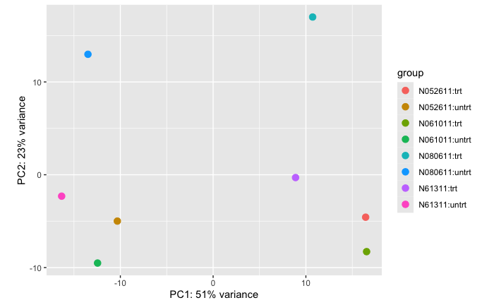

2. Using `PCAtools`

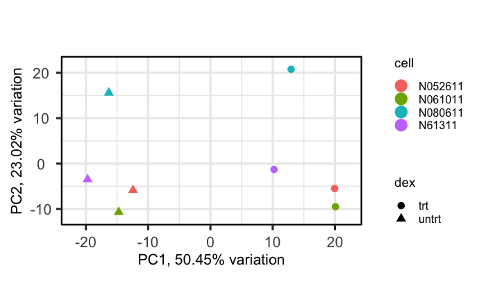

We can color or shape the plot by every variable that exist in our metadata column. It is a good practice to play with them, because it might help identify sources of technical variability that can be accounted for in the DESeq design.

# DESeq2 workflow: Part II

## Differential expression test

```r
resultsNames(dds)
```

```
[1] "Intercept"               "cell_N061011_vs_N052611" "cell_N080611_vs_N052611" "cell_N61311_vs_N052611"  "dex_untrt_vs_trt"
```

We can obtain a summary of our results

```r
summary(deg_table)
```

```
out of 13055 with nonzero total read count
adjusted p-value < 0.05
LFC > 0 (up)       : 2023, 15%
LFC < 0 (down)     : 1810, 14%
outliers [1]       : 0, 0%
low counts [2]     : 0, 0%
(mean count < 7)
[1] see 'cooksCutoff' argument of ?results
[2] see 'independentFiltering' argument of ?results
```

Out of 13055 tested genes 2023 are expressed higher after the treatment than in control (upregulated) and 1810 are expressed lower after the treatment than in the control (downregulated)

```r
head(deg_table)
```

```
log2 fold change (MLE): dex trt vs untrt
Wald test p-value: dex trt vs untrt
DataFrame with 6 rows and 6 columns
          baseMean log2FoldChange     lfcSE      stat      pvalue        padj
         <numeric>      <numeric> <numeric> <numeric>   <numeric>   <numeric>
TSPAN6    710.9158     -0.3931908 0.0998361 -3.938363 8.20395e-05 5.63698e-04
DPM1      521.6303      0.1949073 0.1111022  1.754306 7.93780e-02 1.86583e-01
SCYL3     237.8129      0.0260166 0.1411996  0.184254 8.53814e-01 9.17415e-01
C1orf112   58.0856     -0.1011193 0.2816812 -0.358985 7.19606e-01 8.35955e-01
CFH      5828.5177      0.4144223 0.0882714  4.694864 2.66784e-06 2.57228e-05
FUCA2    1286.2427     -0.2530304 0.0885088 -2.858817 4.25225e-03 1.78901e-02
```

`deg_table` is the main result of the analysis. It has one row per gene and answers the question: “did this gene change after dexamethasone treatment, and by how much?” The columns are:

- `baseMean` - average normalized expression of the gene across all samples. Tells you how highly the gene is expressed overall.
- `log2FoldChange` - the size and direction of the change (treated vs. untreated). A value of 1 means 2x higher in treated, -1 means 2x lower, 0 means no change.
- `lfcSE` - standard error of the log2 fold change, i.e. how uncertain that estimate is.
- `stat` - the Wald test statistic (`log2FoldChange / lfcSE`). The p-value is derived from it.
- `pvalue` - the probability of seeing a change at least this large if the gene was **not** truly affected by the treatment.
- `padj` - the p-value adjusted for multiple testing. **This is the value to use to call genes significant.**

## Adjusted p-value and multiple testing correction

A p-value of 0.05 means that there is a 5% chance of getting a result this extreme just by luck, even if nothing is going on. That is fine for one test, but here we test ~13,000 genes at once. If none of the genes were truly changed, we would still expect 0.05 × 13,000 = **~650 genes** with p < 0.05 purely by chance. These false positives would be mixed in with the real hits, and we could not tell which are which.

```r
sum(deg_table$pvalue < 0.05)
```

```
[1] 4959
```

If we hadn’t correct the p-value for multiple testing, we would have to expect that 13% of “significant” genes could be actually not significant - false positive

**Multiple testing correction** fixes this by making the threshold stricter the more genes we test. DESeq2 uses the Benjamini-Hochberg method, which controls the **false discovery rate (FDR)**. The adjusted p-value (`padj`) is the expected proportion of false positives among the genes called significant at that cutoff. For example, if we keep all genes with `padj` < 0.05, we accept that about 5% of them may be false positives.

```r
0.05 * sum(deg_table$padj < 0.05)
```

```
[1] 191.65
```

A useful metric or test to check if our differential expression test was well calibrated and the results are reliable is to look the distribution of nominal (raw) p-values

Why it matters. Multiple testing correction, including Benjamini-Hochberg, assumes the null p-values are uniform. If they aren’t, padj and the FDR it promises are unreliable, and the list of significant genes may contain many more false positives, or miss many more real ones, than stated.

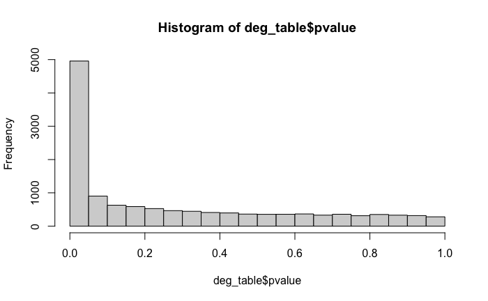

In our case the histogram looks perfect - our test is well-calibrated.